# Exam project for Bayesian statistics course

UNITS University, DSSC Master degree, year 2018/2019

Domagoj Korais

July 16, 2019

# Project aim and description

In this project I studied the relationship between **UVB dose** and **melanoma mortality rate**, using a **hierarchical** model to account for the multilevel grouping of the data. Additionaly a comparison with the following paper has been performed:

> Langford, I.H., Bentham, G. and McDonald, A. (1998). Multilevel modelling of geographically aggregated health data: a case study on malignant melanoma mortality and UV exposure in the European community. *Statistics in Medicine*, *17*, 41-58.

[Link to the paper](https://onlinelibrary.wiley.com/doi/abs/10.1002/%28SICI%291097-0258%2819980115%2917%3A1%3C41%3A%3AAID-SIM712%3E3.0.CO%3B2-0)

# Dataset description

[mmmec library](https://www.rdocumentation.org/packages/R2MLwiN/versions/0.8-6/topics/mmmec)

## Variables

There is a total of six variables and 354 observations:

- `nation` a factor with levels `Belgium`, `W.Germany`, `Denmark`, `France`, `UK`, `Italy`, `Ireland`, `Luxembourg`, and `Netherlands`
- `region` Region ID - a factor
- `county` County ID - a factor
- `deaths` Number of male deaths due to malignant melanoma during 1971-1980*
- `expected` Number of expected deaths (proportional to population)
- `uvb` Centered measure of the UVB dose reaching the earth’s surface in each county.**

`* for the United Kingdom, Ireland, Germany, Italy and The Netherlands, data were only available from 1975—1976 onwards. This information is not present in the package documentation but only in the paper`

`** in the paper the measure is not centered`

The data are **geographically nested**, since nations are divided in regions, and regions are divided in counties. A county is the smallest area forwich we have data.

## Hierarchy

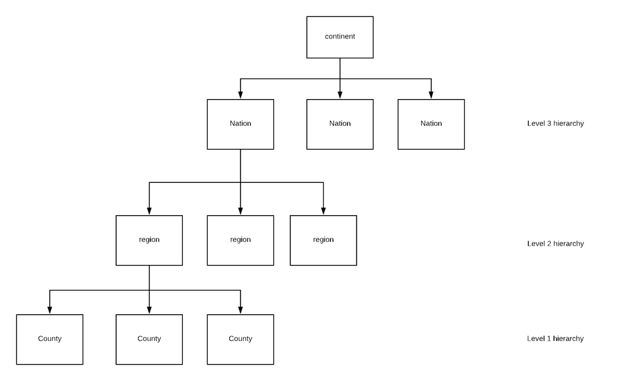

And relative counts:

Data hierarchy

| number | nation | regions | counties |
| --- | --- | --- | --- |
| 1 | Belgium | 3 | 11 |
| 2 | W.Germany | 11 | 30 |
| 3 | Denmark | 3 | 14 |
| 4 | France | 21 | 94 |
| 5 | UK | 11 | 70 |
| 6 | Italy | 20 | 95 |
| 7 | Ireland | 4 | 26 |
| 8 | Luxembourg | 1 | 3 |
| 9 | Netherlands | 4 | 11 |

As we can see the groupings are very eterogenious between nations.

# Explorative data analysis

Let’s check the distributions of the variables in the dataset.

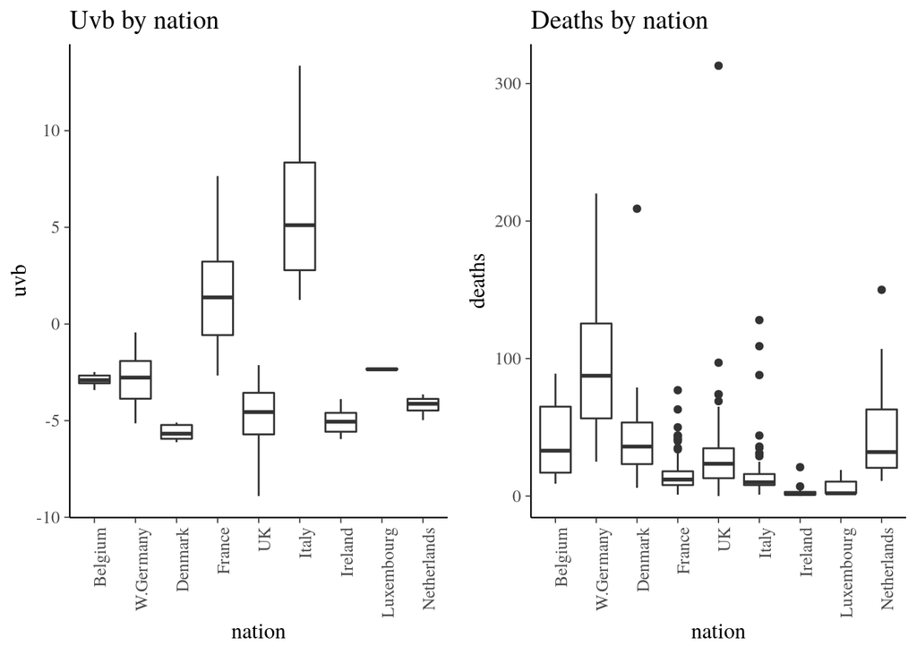

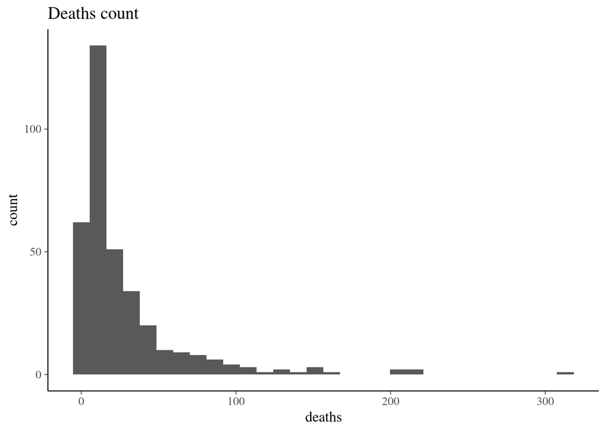

Descriptive statistics for UVB

| nation | N | mean | sd | min | max |
| --- | --- | --- | --- | --- | --- |
| Belgium | 11 | -2.89 | 0.29 | -3.42 | -2.49 |
| W.Germany | 30 | -2.79 | 1.35 | -5.14 | -0.44 |
| Denmark | 14 | -5.63 | 0.38 | -6.12 | -5.10 |
| France | 94 | 1.59 | 2.59 | -2.67 | 7.65 |
| UK | 70 | -4.68 | 1.50 | -8.90 | -2.13 |
| Italy | 95 | 5.86 | 3.51 | 1.24 | 13.36 |
| Ireland | 26 | -5.05 | 0.60 | -5.95 | -3.88 |
| Luxembourg | 3 | -2.33 | 0.05 | -2.37 | -2.28 |
| Netherlands | 11 | -4.19 | 0.47 | -4.97 | -3.64 |

As we can see from a comparison with Table 3 of the paper the values are not the same, since they used a non centered parametrization.

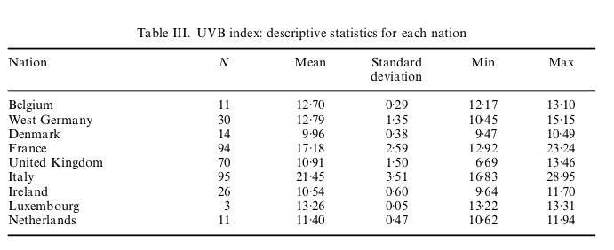

Figure 3 paper

## Correlation plots

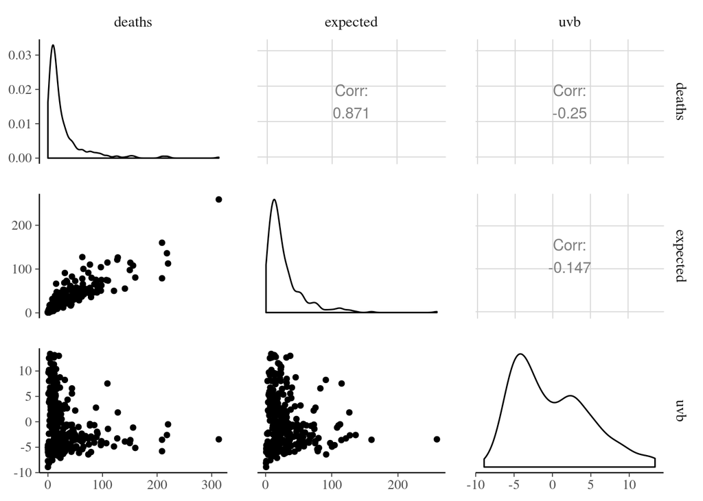

There is no linear relation between deaths and uvb.

# Modelling

## Goals

The model proposed is a **double nested negative binomial model**, two models are presented: model A and model B, they reflect the models of the paper but with a negative binomial instead of a Poisson distribution. The nesting is performed on nations, and for every nation on the regions.

The model focus on two aspects:

- investigate the importance of nested nature of the data (both for model accuracy and variance analysis)
- investigate the relation between UVB dose and mortality rate

## model A:

$$deaths_{ijk}=NB(ln(O_{ijk}),\phi)$$
$$ln(O_{ijk}) = ln(E_{ijk})+\alpha+\beta*UVB_{ijk} +s_k+u_{jk}+e_{ijk}$$
$$s_k\sim N(0,\sigma^2_{s})$$
$$u_{jk}\sim N(0,\sigma^2_{u})$$

## model B:

$$ln(O_{ijk}) = ln(E_{ijk})+\alpha+\beta*UVB_{ijk} +s_k +$$
$$+ t_k*UVB_{ijk} + u_{jk} + v_{jk}*UVB_{ijk} + e_{ijk})$$
$$s_k\sim N(0,\sigma^2_{s})$$

$$t_{k}\sim N(0,\sigma^2_{t})$$

$$u_{jk}\sim N(0,\sigma^2_{u})$$
$$v_{jk}\sim N(0,\sigma^2_{v})$$

explanation of the symbols:

- $i$ represents a county, $j$ represents a region and $k$ represents a nation.
- $E_{ijk}$ is the exposure given in the dataset
- $s_k$,$t_k$ the variations at national level
- $u_{jk}$,$v_{jk}$are the variations at regional level nested in nations
- $e_{ijk}$ is the randdom variation at county level

## Stan code used for model B:

The model has been runned using 4 chains, a warmup period of 2000(default) and 4000 iterations, leaving other parameters as default ones. To replicate the results compile this same Rmd file changing setting `recompute=TRUE` in the setup section.

```
##
## //reproduce model B of Langford, I.H., Bentham, G. and McDonald, A. (1998). Multilevel modelling of geographically aggregated health data: a case study on malignant melanoma mortality and UV exposure in the European community. Statistics in Medicine, 17, 41-58.
## functions {
##   int neg_binomial_2_log_safe_rng(real eta, real phi) {
##     real gamma_rate = gamma_rng(phi, phi / exp(eta));
##     if (gamma_rate >= exp(20.79))
##       return -9;
##   return poisson_rng(gamma_rate);
## }
##
## }
## data {
##
##   int<lower=1> N;//number of records (level 1 counties)
##   int<lower=1> L;//numero di regioni (level 2 groups)
##   int<lower=1> J;//numero di nazioni (level 3 groups)
##
##   int<lower=0> deaths[N]; //number of deaths
##   vector<lower=-10>[N] uvb;//uvb value
##   vector[N] population;  //exposure
##
##   int<lower=0> region_id[N]; //region
##   int<lower=0> nation_id[N]; //nation
##   int<lower=1,upper=J> nationWithinRegion[L];
##
## }
##
## parameters {//default is weakly informative
##   real<lower=0> inv_phi;
##   real beta;
##   real alpha; //the intercept
##
##
##   //the deviation from the intercept at the different levels
##   real dev_reg[L]; //deviation between the regions within a nation
##   real dev_nat[J]; //deviation between the nations
##   real dev_beta_nat[J];
##   real dev_beta_reg[L];
##   //the standard deviation for the deviations
##   real<lower=0> sigma_reg;
```

[output cut: 55 more lines]

```
##
## generated quantities {
##   real eta_rep[N];
##   int y_rep[N];
##   vector[N] log_lik;
##
##   for (n in 1:N) {
##
##     real eta_n = alpha_reg[region_id[n]] + beta_reg[region_id[n]] .* uvb[n] + population[n];
##     eta_rep[n]=eta_n;
##     y_rep[n] = neg_binomial_2_log_safe_rng(eta_n, phi);
##     log_lik[n] = neg_binomial_2_log_lpmf(deaths[n]| eta_n, phi);
##
##   }
## }
```

## Model checking

### Residuals

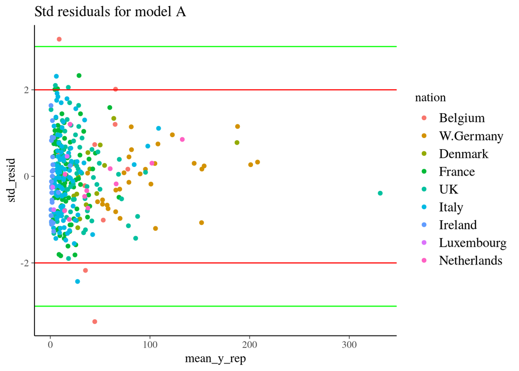

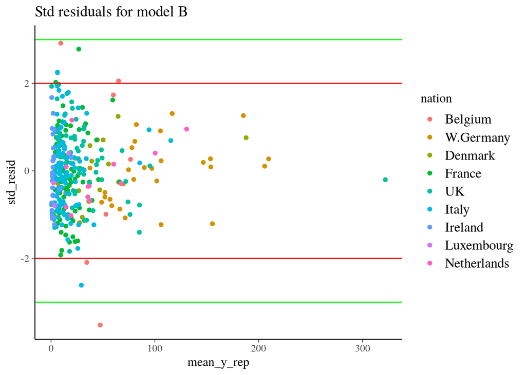

### Model comparison

- model1 mathces modelA,
- model2 matches modelB with non informative priors
- model3 matches modelB with custom priors, selected in such a way to shorten the tails of posteriors distributions

Loo comparisons

|  | elpd_diff | se_diff | elpd_loo | se_elpd_loo | p_loo | se_p_loo | looic | se_looic |
| --- | --- | --- | --- | --- | --- | --- | --- | --- |
| model3 | 0.00 | 0.00 | -1055.67 | 22.50 | 54.87 | 6.12 | 2111.34 | 45.00 |
| model2 | -0.27 | 1.62 | -1055.93 | 22.95 | 49.98 | 6.39 | 2111.87 | 45.90 |
| model1 | -6.14 | 3.59 | -1061.80 | 21.80 | 52.69 | 5.83 | 2123.61 | 43.59 |

### Posterior predictive checks

As we can check from the following graphs the model fits well the data.

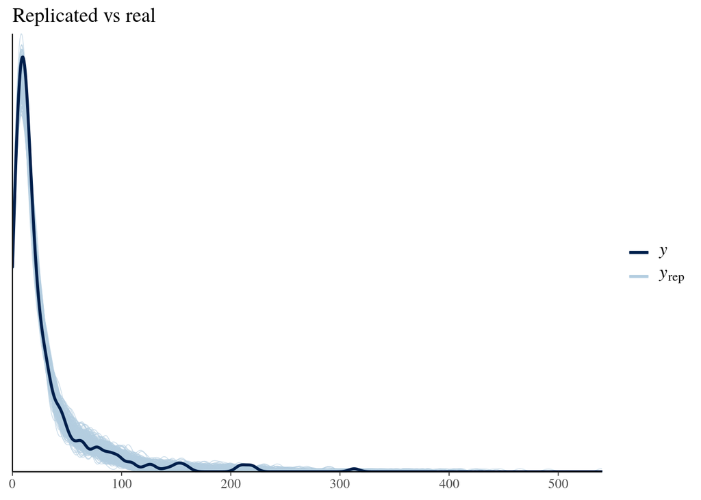

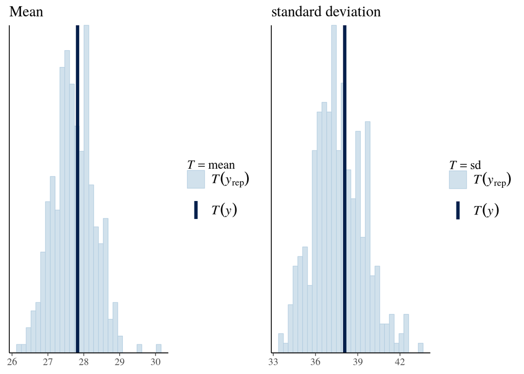

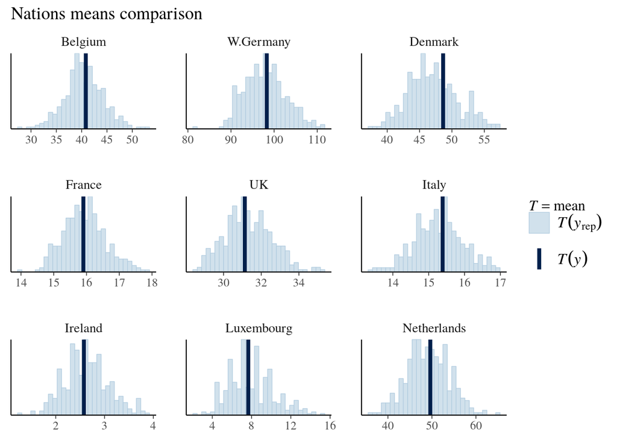

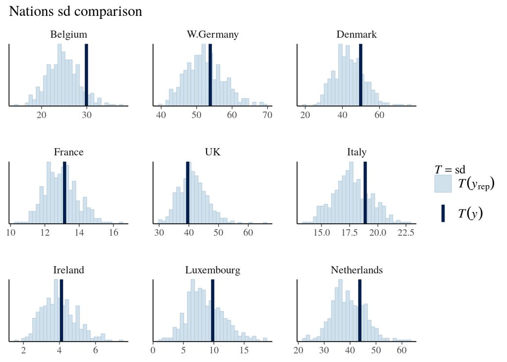

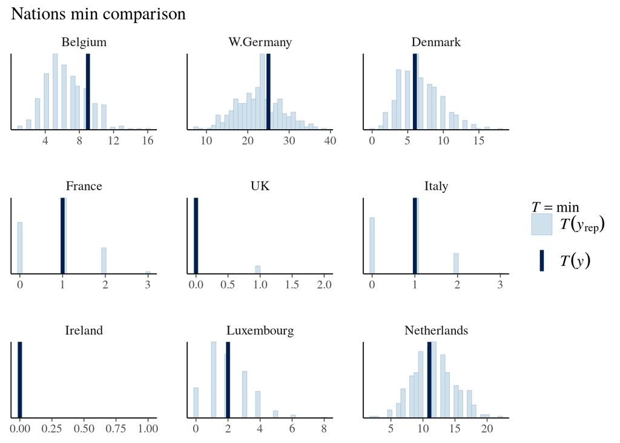

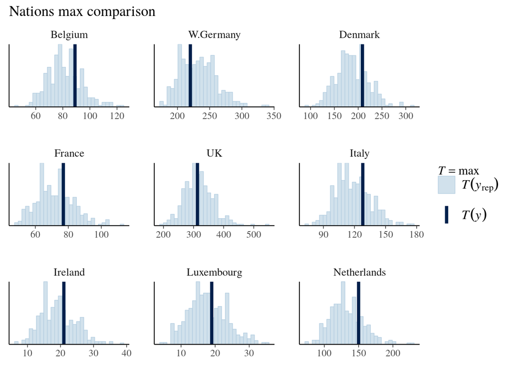

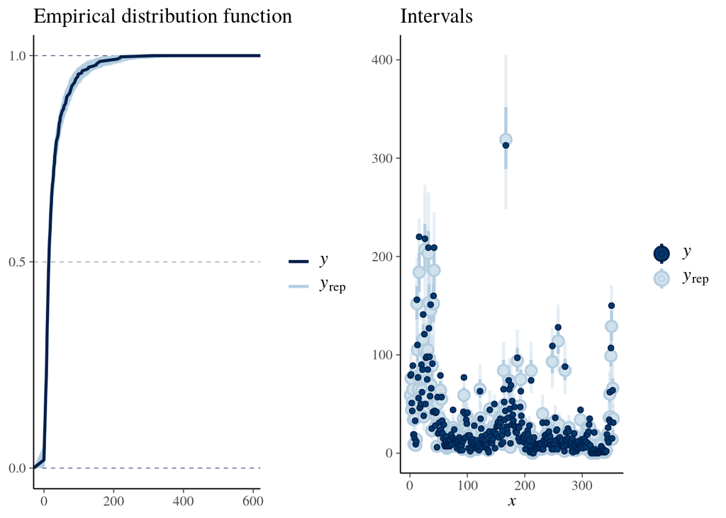

## Model inferences

### Parameters

The estimated parameters are graphically shown in the next plots: The fixed therms are both compatible with 0, so are the region level ones. From the last plot it is clear that the relation between UVB index and death rates shows large variations between countries, in fact for **UK**, **Ireland**, **Belgium**, **France**, **Luxemburg** we have a positive relation, instead for **W.Germany**, **Denmark**, **Italy**, **Netherland** a negative one. This fact alone shows that in this kind of analysis taking into account the hierarchical nature of data is of paramount importance.

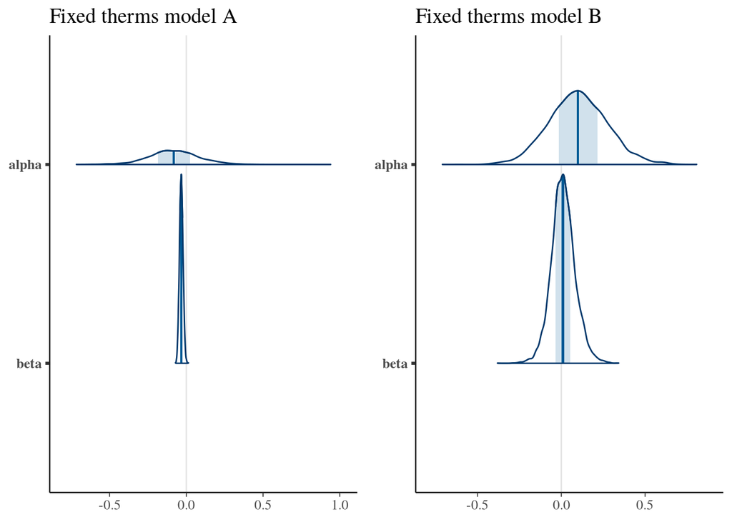

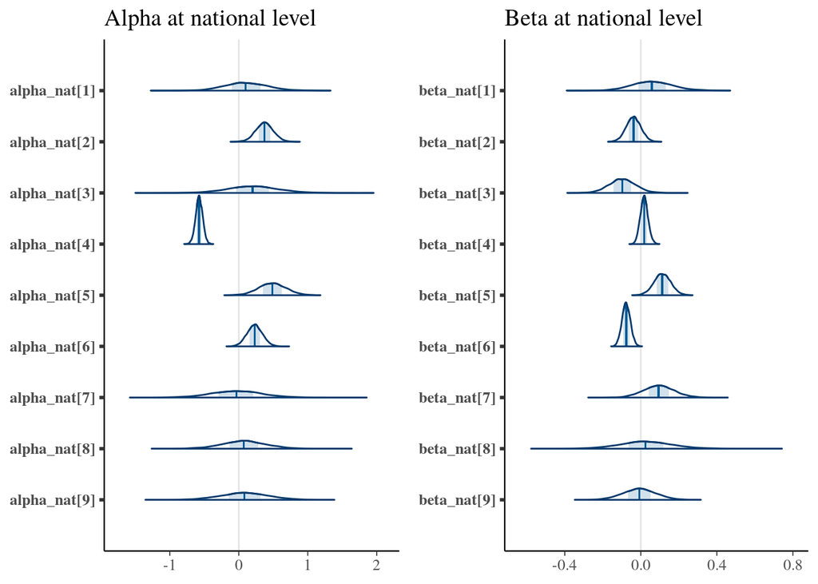

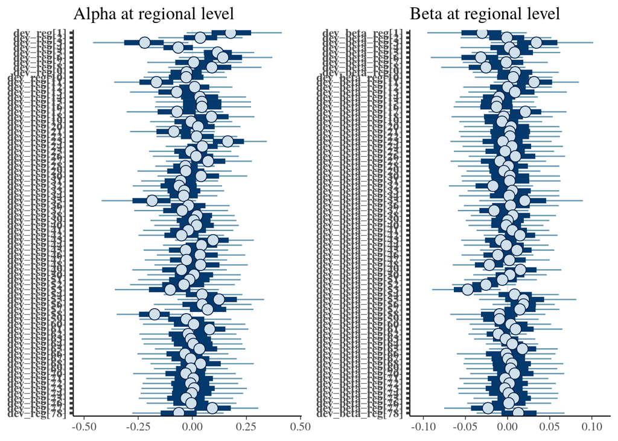

### Variance

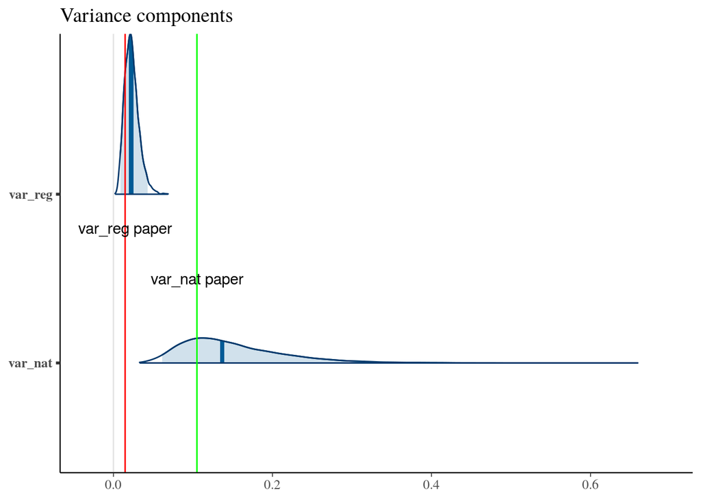

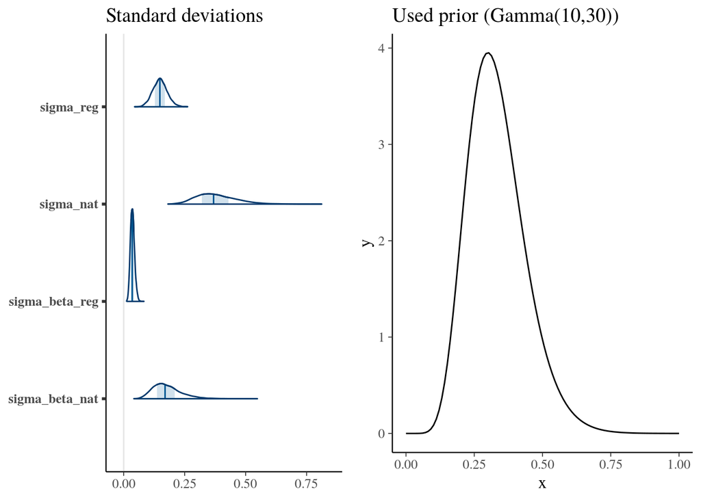

# Comparison with paper

### Parameters

Model B values between 25 and 75 percentiles

| parameter | modelA_mean | modelA_sd | modelB_mean | modelB_sd | mean | se_mean | sd | X2.5. | X25. | X50. | X75. | X97.5. | n_eff | Rhat |
| --- | --- | --- | --- | --- | --- | --- | --- | --- | --- | --- | --- | --- | --- | --- |
| alpha | 0.01 | 0.13 | 0.19 | 0.14 | 0.10 | 0 | 0.17 | -0.23 | -0.02 | 0.10 | 0.22 | 0.45 | 3176.60 | 1 |
| beta | -0.04 | 0.01 | 0.00 | 0.03 | 0.01 | 0 | 0.07 | -0.13 | -0.03 | 0.01 | 0.05 | 0.16 | 1718.21 | 1 |
| var_nat | 0.14 | 0.07 | 0.10 | 0.07 | 0.15 | 0 | 0.07 | 0.06 | 0.10 | 0.14 | 0.19 | 0.32 | 7858.36 | 1 |
| var_reg | 0.04 | 0.01 | 0.01 | 0.00 | 0.02 | 0 | 0.01 | 0.01 | 0.02 | 0.02 | 0.03 | 0.04 | 1591.95 | 1 |

Beta pooled values between 2.5 and 97.5 percentiles

| nation | estimate | sd.x | mean | se_mean | sd.y | X2.5. | X25. | X50. | X75. | X97.5. | n_eff | Rhat | delta_sd |
| --- | --- | --- | --- | --- | --- | --- | --- | --- | --- | --- | --- | --- | --- |
| France | 0.00 | 0.04 | 0.02 | 0 | 0.02 | -0.02 | 0.00 | 0.02 | 0.03 | 0.06 | 9069.10 | 1 | -47.77 |
| Italy | -0.05 | 0.04 | -0.08 | 0 | 0.02 | -0.12 | -0.09 | -0.08 | -0.06 | -0.03 | 5825.74 | 1 | -44.32 |
| W.Germany | -0.01 | 0.04 | -0.04 | 0 | 0.04 | -0.11 | -0.06 | -0.04 | -0.01 | 0.04 | 9321.73 | 1 | -11.75 |
| UK | 0.08 | 0.05 | 0.11 | 0 | 0.04 | 0.03 | 0.08 | 0.11 | 0.14 | 0.20 | 8287.71 | 1 | -8.60 |
| Denmark | -0.07 | 0.07 | -0.10 | 0 | 0.07 | -0.23 | -0.14 | -0.10 | -0.05 | 0.04 | 8564.02 | 1 | -1.12 |
| Ireland | 0.02 | 0.06 | 0.09 | 0 | 0.08 | -0.07 | 0.04 | 0.09 | 0.15 | 0.26 | 7583.37 | 1 | 40.83 |
| Netherlands | 0.00 | 0.06 | -0.01 | 0 | 0.09 | -0.18 | -0.07 | -0.01 | 0.05 | 0.17 | 6997.56 | 1 | 58.94 |
| Belgium | 0.02 | 0.06 | 0.06 | 0 | 0.11 | -0.14 | -0.01 | 0.06 | 0.13 | 0.29 | 6780.44 | 1 | 72.86 |
| Luxembourg | 0.00 | 0.06 | 0.03 | 0 | 0.14 | -0.25 | -0.06 | 0.02 | 0.12 | 0.31 | 6738.10 | 1 | 130.61 |

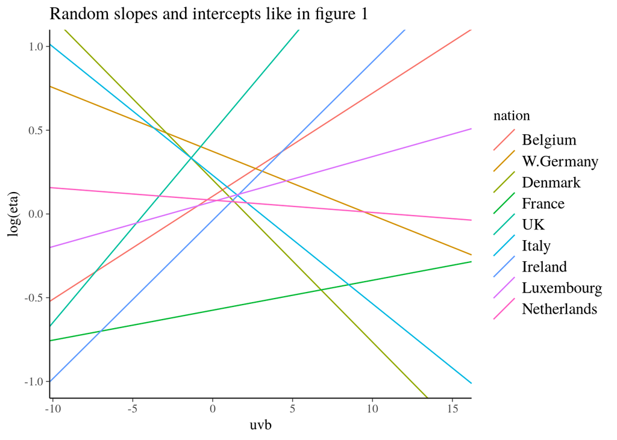

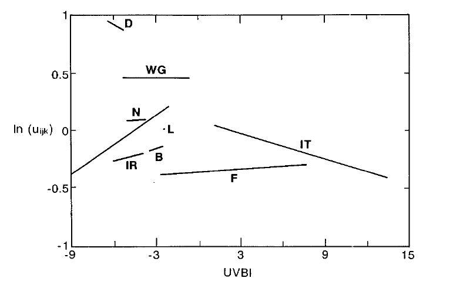

### Variance

[output not shown]

## Conclusions

- The obtained results are compatible with those from the paper.
- There is a relationship between UVB exposure and death rates but it is highly dependent on the nation.
- The variance is much higher at national level, than between regions of the same nation.
- Taking into account the hierarchical nature of data is of vital importance here, for example model A shows a spurious negative correlation hxpoure and mortality rate, but this correlation disappears in model B.
- It would be interesting to have more explanatory variables, and to have the mapping between regions/counties and their physical location, unfortunately I was not able to find this information anywhere, and the original cancer atlas from where data are taken is not aviable anywhere on the net.

## Additional notes

- I tried to do a pull request on the GitHub page of the package to fix the information about the dataset, but the GitHub page appears to be only a read-only mirror.
- Some fitted models exceeded the maximum size allowed by GitHub (100 Mb) and committing them blocked my work, I had to revert all my local changes to fix the problem, so take care committing compiling models.

## Appendix

Here I list all the computed parameters for model B

|  | mean | se_mean | sd | 2.5% | 25% | 50% | 75% | 97.5% | n_eff | Rhat |
| --- | --- | --- | --- | --- | --- | --- | --- | --- | --- | --- |
| alpha | 0.1 | 0 | 0.17 | -0.23 | -0.02 | 0.1 | 0.22 | 0.45 | 3176.6 | 1 |

|  | mean | se_mean | sd | 2.5% | 25% | 50% | 75% | 97.5% | n_eff | Rhat |
| --- | --- | --- | --- | --- | --- | --- | --- | --- | --- | --- |
| beta | 0.01 | 0 | 0.07 | -0.13 | -0.03 | 0.01 | 0.05 | 0.16 | 1718.21 | 1 |

|  | mean | se_mean | sd | 2.5% | 25% | 50% | 75% | 97.5% | n_eff | Rhat |
| --- | --- | --- | --- | --- | --- | --- | --- | --- | --- | --- |
| beta_nat[1] | 0.06 | 0 | 0.11 | -0.14 | -0.01 | 0.06 | 0.13 | 0.29 | 6780.44 | 1 |
| beta_nat[2] | -0.04 | 0 | 0.04 | -0.11 | -0.06 | -0.04 | -0.01 | 0.04 | 9321.73 | 1 |
| beta_nat[3] | -0.10 | 0 | 0.07 | -0.23 | -0.14 | -0.10 | -0.05 | 0.04 | 8564.02 | 1 |
| beta_nat[4] | 0.02 | 0 | 0.02 | -0.02 | 0.00 | 0.02 | 0.03 | 0.06 | 9069.10 | 1 |
| beta_nat[5] | 0.11 | 0 | 0.04 | 0.03 | 0.08 | 0.11 | 0.14 | 0.20 | 8287.71 | 1 |
| beta_nat[6] | -0.08 | 0 | 0.02 | -0.12 | -0.09 | -0.08 | -0.06 | -0.03 | 5825.74 | 1 |
| beta_nat[7] | 0.09 | 0 | 0.08 | -0.07 | 0.04 | 0.09 | 0.15 | 0.26 | 7583.37 | 1 |
| beta_nat[8] | 0.03 | 0 | 0.14 | -0.25 | -0.06 | 0.02 | 0.12 | 0.31 | 6738.10 | 1 |
| beta_nat[9] | -0.01 | 0 | 0.09 | -0.18 | -0.07 | -0.01 | 0.05 | 0.17 | 6997.56 | 1 |

|  | mean | se_mean | sd | 2.5% | 25% | 50% | 75% | 97.5% | n_eff | Rhat |
| --- | --- | --- | --- | --- | --- | --- | --- | --- | --- | --- |
| alpha_nat[1] | 0.11 | 0 | 0.31 | -0.48 | -0.10 | 0.10 | 0.31 | 0.73 | 6974.50 | 1 |
| alpha_nat[2] | 0.37 | 0 | 0.13 | 0.12 | 0.29 | 0.37 | 0.46 | 0.62 | 7908.65 | 1 |
| alpha_nat[3] | 0.20 | 0 | 0.37 | -0.52 | -0.04 | 0.20 | 0.44 | 0.95 | 8510.73 | 1 |
| alpha_nat[4] | -0.57 | 0 | 0.05 | -0.68 | -0.61 | -0.57 | -0.54 | -0.47 | 8558.44 | 1 |
| alpha_nat[5] | 0.49 | 0 | 0.20 | 0.10 | 0.35 | 0.49 | 0.62 | 0.89 | 7845.03 | 1 |
| alpha_nat[6] | 0.23 | 0 | 0.11 | 0.01 | 0.16 | 0.23 | 0.31 | 0.45 | 7790.67 | 1 |
| alpha_nat[7] | -0.04 | 0 | 0.38 | -0.80 | -0.29 | -0.03 | 0.21 | 0.71 | 6723.23 | 1 |
| alpha_nat[8] | 0.07 | 0 | 0.33 | -0.59 | -0.14 | 0.07 | 0.28 | 0.71 | 6972.57 | 1 |
| alpha_nat[9] | 0.08 | 0 | 0.35 | -0.61 | -0.15 | 0.08 | 0.32 | 0.78 | 7214.22 | 1 |

|  | mean | se_mean | sd | 2.5% | 25% | 50% | 75% | 97.5% | n_eff | Rhat |
| --- | --- | --- | --- | --- | --- | --- | --- | --- | --- | --- |
| beta_reg[1] | 0.03 | 0 | 0.11 | -0.19 | -0.04 | 0.03 | 0.10 | 0.25 | 6660.14 | 1 |
| beta_reg[2] | 0.06 | 0 | 0.11 | -0.14 | -0.01 | 0.06 | 0.13 | 0.28 | 6979.15 | 1 |
| beta_reg[3] | 0.10 | 0 | 0.11 | -0.11 | 0.02 | 0.10 | 0.17 | 0.33 | 6563.65 | 1 |
| beta_reg[4] | -0.04 | 0 | 0.05 | -0.14 | -0.07 | -0.04 | 0.00 | 0.07 | 11953.07 | 1 |
| beta_reg[5] | -0.03 | 0 | 0.05 | -0.12 | -0.06 | -0.03 | 0.00 | 0.06 | 11935.79 | 1 |
| beta_reg[6] | -0.07 | 0 | 0.05 | -0.17 | -0.10 | -0.07 | -0.04 | 0.02 | 7956.58 | 1 |
| beta_reg[7] | -0.04 | 0 | 0.05 | -0.13 | -0.07 | -0.04 | -0.01 | 0.05 | 10407.06 | 1 |
| beta_reg[8] | -0.06 | 0 | 0.04 | -0.15 | -0.09 | -0.07 | -0.04 | 0.02 | 8828.35 | 1 |
| beta_reg[9] | -0.03 | 0 | 0.05 | -0.13 | -0.06 | -0.03 | 0.00 | 0.07 | 9323.70 | 1 |
| beta_reg[10] | -0.03 | 0 | 0.04 | -0.12 | -0.06 | -0.03 | 0.00 | 0.05 | 8652.15 | 1 |
| beta_reg[11] | -0.01 | 0 | 0.05 | -0.10 | -0.04 | -0.01 | 0.03 | 0.09 | 4690.01 | 1 |
| beta_reg[12] | -0.04 | 0 | 0.05 | -0.14 | -0.07 | -0.04 | 0.00 | 0.06 | 10513.43 | 1 |
| beta_reg[13] | -0.03 | 0 | 0.05 | -0.13 | -0.06 | -0.03 | 0.01 | 0.08 | 9222.86 | 1 |
| beta_reg[14] | -0.05 | 0 | 0.04 | -0.13 | -0.08 | -0.05 | -0.02 | 0.03 | 9918.35 | 1 |
| beta_reg[15] | -0.11 | 0 | 0.07 | -0.25 | -0.16 | -0.11 | -0.06 | 0.03 | 8530.55 | 1 |
| beta_reg[16] | -0.11 | 0 | 0.07 | -0.26 | -0.16 | -0.11 | -0.06 | 0.04 | 8640.64 | 1 |
| beta_reg[17] | -0.07 | 0 | 0.07 | -0.21 | -0.12 | -0.07 | -0.03 | 0.06 | 8514.23 | 1 |
| beta_reg[18] | 0.01 | 0 | 0.04 | -0.07 | -0.01 | 0.01 | 0.04 | 0.09 | 13905.41 | 1 |
| beta_reg[19] | 0.01 | 0 | 0.03 | -0.05 | -0.01 | 0.01 | 0.03 | 0.07 | 11430.79 | 1 |
| beta_reg[20] | 0.02 | 0 | 0.04 | -0.06 | 0.00 | 0.02 | 0.05 | 0.10 | 12365.39 | 1 |
| beta_reg[21] | 0.02 | 0 | 0.04 | -0.06 | -0.01 | 0.02 | 0.05 | 0.11 | 13665.71 | 1 |
| beta_reg[22] | 0.02 | 0 | 0.04 | -0.06 | -0.01 | 0.02 | 0.05 | 0.10 | 12204.49 | 1 |
| beta_reg[23] | 0.01 | 0 | 0.04 | -0.07 | -0.02 | 0.01 | 0.04 | 0.09 | 12884.13 | 1 |
| beta_reg[24] | 0.02 | 0 | 0.04 | -0.06 | 0.00 | 0.02 | 0.05 | 0.11 | 11948.58 | 1 |
| beta_reg[25] | 0.01 | 0 | 0.04 | -0.07 | -0.01 | 0.01 | 0.04 | 0.10 | 14055.07 | 1 |
| beta_reg[26] | 0.03 | 0 | 0.04 | -0.05 | 0.00 | 0.03 | 0.05 | 0.11 | 10013.76 | 1 |
| beta_reg[27] | 0.01 | 0 | 0.04 | -0.07 | -0.02 | 0.01 | 0.03 | 0.08 | 12141.88 | 1 |
| beta_reg[28] | 0.02 | 0 | 0.04 | -0.06 | -0.01 | 0.02 | 0.05 | 0.10 | 12464.98 | 1 |
| beta_reg[29] | 0.01 | 0 | 0.03 | -0.04 | 0.00 | 0.01 | 0.03 | 0.06 | 10824.65 | 1 |
| beta_reg[30] | 0.02 | 0 | 0.04 | -0.06 | -0.01 | 0.02 | 0.05 | 0.10 | 10544.50 | 1 |
| beta_reg[31] | 0.02 | 0 | 0.04 | -0.06 | -0.01 | 0.02 | 0.05 | 0.10 | 11209.41 | 1 |
| beta_reg[32] | 0.00 | 0 | 0.03 | -0.06 | -0.02 | 0.00 | 0.02 | 0.06 | 8585.33 | 1 |
| beta_reg[33] | 0.02 | 0 | 0.04 | -0.05 | 0.00 | 0.02 | 0.05 | 0.10 | 10745.39 | 1 |
| beta_reg[34] | 0.02 | 0 | 0.04 | -0.06 | -0.01 | 0.02 | 0.05 | 0.10 | 13711.86 | 1 |
| beta_reg[35] | 0.04 | 0 | 0.04 | -0.04 | 0.01 | 0.04 | 0.07 | 0.13 | 6379.72 | 1 |
| beta_reg[36] | 0.02 | 0 | 0.04 | -0.06 | 0.00 | 0.02 | 0.05 | 0.10 | 11630.41 | 1 |
| beta_reg[37] | 0.00 | 0 | 0.02 | -0.05 | -0.02 | 0.00 | 0.02 | 0.05 | 9972.08 | 1 |
| beta_reg[38] | 0.02 | 0 | 0.03 | -0.04 | 0.00 | 0.02 | 0.05 | 0.09 | 10731.99 | 1 |
| beta_reg[39] | 0.11 | 0 | 0.05 | 0.01 | 0.08 | 0.11 | 0.15 | 0.22 | 9704.11 | 1 |
| beta_reg[40] | 0.11 | 0 | 0.05 | 0.01 | 0.08 | 0.11 | 0.14 | 0.21 | 9631.11 | 1 |
| beta_reg[41] | 0.12 | 0 | 0.05 | 0.03 | 0.09 | 0.12 | 0.15 | 0.21 | 8592.22 | 1 |
| beta_reg[42] | 0.13 | 0 | 0.05 | 0.03 | 0.10 | 0.13 | 0.16 | 0.23 | 7446.11 | 1 |
| beta_reg[43] | 0.11 | 0 | 0.05 | 0.00 | 0.07 | 0.11 | 0.14 | 0.21 | 10548.47 | 1 |
| beta_reg[44] | 0.11 | 0 | 0.06 | 0.00 | 0.07 | 0.11 | 0.15 | 0.23 | 10090.00 | 1 |
| beta_reg[45] | 0.12 | 0 | 0.05 | 0.03 | 0.09 | 0.12 | 0.16 | 0.23 | 7767.32 | 1 |
| beta_reg[46] | 0.10 | 0 | 0.05 | 0.01 | 0.07 | 0.10 | 0.13 | 0.19 | 8526.82 | 1 |
| beta_reg[47] | 0.12 | 0 | 0.05 | 0.01 | 0.08 | 0.12 | 0.15 | 0.22 | 8818.58 | 1 |
| beta_reg[48] | 0.09 | 0 | 0.04 | 0.01 | 0.06 | 0.09 | 0.12 | 0.17 | 9440.50 | 1 |
| beta_reg[49] | 0.13 | 0 | 0.05 | 0.04 | 0.10 | 0.13 | 0.16 | 0.22 | 8108.65 | 1 |
| beta_reg[50] | -0.07 | 0 | 0.03 | -0.14 | -0.10 | -0.07 | -0.05 | -0.01 | 9619.44 | 1 |
| beta_reg[51] | -0.08 | 0 | 0.03 | -0.14 | -0.10 | -0.08 | -0.06 | -0.02 | 13821.43 | 1 |
| beta_reg[52] | -0.10 | 0 | 0.02 | -0.15 | -0.12 | -0.10 | -0.09 | -0.06 | 10520.27 | 1 |
| beta_reg[53] | -0.12 | 0 | 0.03 | -0.18 | -0.14 | -0.12 | -0.11 | -0.07 | 6702.17 | 1 |
| beta_reg[54] | -0.07 | 0 | 0.04 | -0.14 | -0.09 | -0.07 | -0.04 | 0.01 | 7850.49 | 1 |
| beta_reg[55] | -0.06 | 0 | 0.04 | -0.14 | -0.08 | -0.06 | -0.03 | 0.04 | 5778.08 | 1 |
| beta_reg[56] | -0.06 | 0 | 0.03 | -0.11 | -0.08 | -0.06 | -0.04 | 0.00 | 6780.67 | 1 |
| beta_reg[57] | -0.06 | 0 | 0.03 | -0.13 | -0.09 | -0.06 | -0.04 | 0.01 | 5894.95 | 1 |
| beta_reg[58] | -0.09 | 0 | 0.04 | -0.17 | -0.11 | -0.09 | -0.06 | 0.00 | 10895.21 | 1 |
| beta_reg[59] | -0.09 | 0 | 0.04 | -0.16 | -0.11 | -0.09 | -0.06 | -0.02 | 11700.11 | 1 |
| beta_reg[60] | -0.07 | 0 | 0.03 | -0.14 | -0.10 | -0.07 | -0.05 | 0.00 | 12402.32 | 1 |
| beta_reg[61] | -0.07 | 0 | 0.04 | -0.14 | -0.09 | -0.07 | -0.04 | 0.02 | 7121.55 | 1 |
| beta_reg[62] | -0.09 | 0 | 0.02 | -0.13 | -0.10 | -0.09 | -0.07 | -0.04 | 10089.39 | 1 |
| beta_reg[63] | -0.08 | 0 | 0.02 | -0.13 | -0.10 | -0.08 | -0.06 | -0.03 | 10722.03 | 1 |
| beta_reg[64] | -0.07 | 0 | 0.02 | -0.10 | -0.08 | -0.07 | -0.06 | -0.04 | 9641.73 | 1 |
| beta_reg[65] | -0.06 | 0 | 0.03 | -0.12 | -0.08 | -0.06 | -0.04 | 0.00 | 7163.56 | 1 |
| beta_reg[66] | -0.08 | 0 | 0.04 | -0.16 | -0.11 | -0.08 | -0.05 | 0.01 | 11541.16 | 1 |
| beta_reg[67] | -0.08 | 0 | 0.04 | -0.15 | -0.10 | -0.08 | -0.05 | 0.00 | 11850.04 | 1 |
| beta_reg[68] | -0.07 | 0 | 0.04 | -0.15 | -0.10 | -0.07 | -0.04 | 0.02 | 9878.99 | 1 |
| beta_reg[69] | -0.07 | 0 | 0.04 | -0.15 | -0.10 | -0.07 | -0.05 | 0.01 | 8286.51 | 1 |
| beta_reg[70] | 0.10 | 0 | 0.08 | -0.06 | 0.05 | 0.10 | 0.16 | 0.27 | 8005.76 | 1 |
| beta_reg[71] | 0.09 | 0 | 0.08 | -0.07 | 0.04 | 0.09 | 0.15 | 0.26 | 7841.01 | 1 |
| beta_reg[72] | 0.10 | 0 | 0.09 | -0.07 | 0.04 | 0.10 | 0.15 | 0.27 | 7604.29 | 1 |
| beta_reg[73] | 0.09 | 0 | 0.09 | -0.08 | 0.03 | 0.09 | 0.15 | 0.26 | 7914.01 | 1 |
| beta_reg[74] | 0.03 | 0 | 0.14 | -0.25 | -0.07 | 0.03 | 0.12 | 0.31 | 6739.88 | 1 |
| beta_reg[75] | 0.00 | 0 | 0.09 | -0.17 | -0.05 | 0.00 | 0.06 | 0.17 | 7271.17 | 1 |
| beta_reg[76] | -0.01 | 0 | 0.09 | -0.19 | -0.07 | -0.01 | 0.06 | 0.17 | 7352.45 | 1 |
| beta_reg[77] | -0.03 | 0 | 0.09 | -0.21 | -0.09 | -0.03 | 0.03 | 0.15 | 7055.41 | 1 |
| beta_reg[78] | 0.01 | 0 | 0.09 | -0.18 | -0.06 | 0.01 | 0.07 | 0.19 | 7330.16 | 1 |

|  | mean | se_mean | sd | 2.5% | 25% | 50% | 75% | 97.5% | n_eff | Rhat |
| --- | --- | --- | --- | --- | --- | --- | --- | --- | --- | --- |
| alpha_reg[1] | 0.29 | 0 | 0.33 | -0.34 | 0.07 | 0.28 | 0.51 | 0.97 | 6564.90 | 1 |
| alpha_reg[2] | 0.14 | 0 | 0.33 | -0.48 | -0.08 | 0.14 | 0.36 | 0.81 | 6749.78 | 1 |
| alpha_reg[3] | -0.12 | 0 | 0.32 | -0.73 | -0.34 | -0.13 | 0.09 | 0.52 | 6546.13 | 1 |
| alpha_reg[4] | 0.31 | 0 | 0.10 | 0.12 | 0.24 | 0.31 | 0.37 | 0.50 | 9175.22 | 1 |
| alpha_reg[5] | 0.49 | 0 | 0.10 | 0.30 | 0.43 | 0.49 | 0.56 | 0.68 | 9266.38 | 1 |
| alpha_reg[6] | 0.52 | 0 | 0.18 | 0.17 | 0.40 | 0.52 | 0.64 | 0.89 | 8541.30 | 1 |
| alpha_reg[7] | 0.38 | 0 | 0.19 | 0.00 | 0.26 | 0.38 | 0.51 | 0.75 | 10861.80 | 1 |
| alpha_reg[8] | 0.47 | 0 | 0.19 | 0.10 | 0.34 | 0.46 | 0.59 | 0.86 | 9004.45 | 1 |
| alpha_reg[9] | 0.35 | 0 | 0.16 | 0.04 | 0.24 | 0.34 | 0.45 | 0.66 | 9561.72 | 1 |
| alpha_reg[10] | 0.34 | 0 | 0.18 | -0.01 | 0.23 | 0.34 | 0.46 | 0.70 | 9398.86 | 1 |
| alpha_reg[11] | 0.21 | 0 | 0.17 | -0.13 | 0.09 | 0.21 | 0.32 | 0.54 | 4505.03 | 1 |
| alpha_reg[12] | 0.38 | 0 | 0.14 | 0.10 | 0.29 | 0.38 | 0.48 | 0.67 | 10039.04 | 1 |
| alpha_reg[13] | 0.30 | 0 | 0.16 | -0.02 | 0.19 | 0.30 | 0.41 | 0.61 | 9276.67 | 1 |
| alpha_reg[14] | 0.41 | 0 | 0.19 | 0.04 | 0.28 | 0.41 | 0.53 | 0.80 | 10247.94 | 1 |
| alpha_reg[15] | 0.25 | 0 | 0.39 | -0.52 | -0.02 | 0.24 | 0.51 | 1.05 | 8610.32 | 1 |
| alpha_reg[16] | 0.25 | 0 | 0.39 | -0.51 | -0.01 | 0.25 | 0.50 | 1.01 | 8720.45 | 1 |
| alpha_reg[17] | 0.13 | 0 | 0.40 | -0.66 | -0.13 | 0.13 | 0.39 | 0.91 | 8571.65 | 1 |
| alpha_reg[18] | -0.49 | 0 | 0.12 | -0.71 | -0.57 | -0.49 | -0.41 | -0.25 | 13240.74 | 1 |
| alpha_reg[19] | -0.58 | 0 | 0.12 | -0.82 | -0.66 | -0.58 | -0.50 | -0.34 | 12035.47 | 1 |
| alpha_reg[20] | -0.55 | 0 | 0.12 | -0.79 | -0.63 | -0.55 | -0.47 | -0.30 | 13467.91 | 1 |
| alpha_reg[21] | -0.66 | 0 | 0.12 | -0.91 | -0.74 | -0.66 | -0.58 | -0.43 | 11231.70 | 1 |
| alpha_reg[22] | -0.55 | 0 | 0.12 | -0.78 | -0.63 | -0.55 | -0.48 | -0.32 | 14692.92 | 1 |
| alpha_reg[23] | -0.41 | 0 | 0.10 | -0.60 | -0.48 | -0.41 | -0.34 | -0.21 | 8146.43 | 1 |
| alpha_reg[24] | -0.53 | 0 | 0.10 | -0.73 | -0.60 | -0.53 | -0.46 | -0.33 | 15951.22 | 1 |
| alpha_reg[25] | -0.58 | 0 | 0.12 | -0.81 | -0.66 | -0.58 | -0.50 | -0.36 | 14312.29 | 1 |
| alpha_reg[26] | -0.56 | 0 | 0.12 | -0.81 | -0.64 | -0.55 | -0.47 | -0.32 | 15722.41 | 1 |
| alpha_reg[27] | -0.50 | 0 | 0.12 | -0.73 | -0.58 | -0.50 | -0.42 | -0.26 | 14084.16 | 1 |
| alpha_reg[28] | -0.61 | 0 | 0.07 | -0.75 | -0.65 | -0.61 | -0.56 | -0.47 | 11466.57 | 1 |
| alpha_reg[29] | -0.61 | 0 | 0.14 | -0.89 | -0.70 | -0.61 | -0.51 | -0.33 | 11504.76 | 1 |
| alpha_reg[30] | -0.53 | 0 | 0.13 | -0.79 | -0.62 | -0.53 | -0.45 | -0.27 | 13579.48 | 1 |
| alpha_reg[31] | -0.63 | 0 | 0.11 | -0.85 | -0.70 | -0.63 | -0.56 | -0.42 | 13954.70 | 1 |
| alpha_reg[32] | -0.64 | 0 | 0.13 | -0.91 | -0.73 | -0.63 | -0.55 | -0.39 | 9803.30 | 1 |
| alpha_reg[33] | -0.61 | 0 | 0.11 | -0.84 | -0.69 | -0.61 | -0.54 | -0.39 | 11723.35 | 1 |
| alpha_reg[34] | -0.62 | 0 | 0.10 | -0.82 | -0.68 | -0.61 | -0.55 | -0.42 | 14137.82 | 1 |
| alpha_reg[35] | -0.77 | 0 | 0.13 | -1.04 | -0.85 | -0.76 | -0.67 | -0.52 | 6220.11 | 1 |
| alpha_reg[36] | -0.59 | 0 | 0.12 | -0.83 | -0.67 | -0.59 | -0.51 | -0.36 | 14735.80 | 1 |
| alpha_reg[37] | -0.62 | 0 | 0.14 | -0.90 | -0.71 | -0.62 | -0.53 | -0.35 | 9744.07 | 1 |
| alpha_reg[38] | -0.55 | 0 | 0.11 | -0.77 | -0.63 | -0.55 | -0.48 | -0.34 | 11231.22 | 1 |
| alpha_reg[39] | 0.49 | 0 | 0.22 | 0.06 | 0.34 | 0.50 | 0.64 | 0.91 | 9612.65 | 1 |
| alpha_reg[40] | 0.51 | 0 | 0.23 | 0.06 | 0.36 | 0.51 | 0.66 | 0.96 | 9660.61 | 1 |
| alpha_reg[41] | 0.47 | 0 | 0.25 | -0.02 | 0.30 | 0.47 | 0.64 | 0.95 | 8552.80 | 1 |
| alpha_reg[42] | 0.44 | 0 | 0.23 | -0.02 | 0.28 | 0.44 | 0.60 | 0.90 | 7962.71 | 1 |
| alpha_reg[43] | 0.59 | 0 | 0.18 | 0.23 | 0.47 | 0.59 | 0.70 | 0.94 | 10004.95 | 1 |
| alpha_reg[44] | 0.53 | 0 | 0.18 | 0.17 | 0.41 | 0.53 | 0.65 | 0.89 | 10004.06 | 1 |
| alpha_reg[45] | 0.46 | 0 | 0.23 | 0.01 | 0.31 | 0.46 | 0.61 | 0.90 | 8270.44 | 1 |
| alpha_reg[46] | 0.53 | 0 | 0.24 | 0.06 | 0.36 | 0.53 | 0.69 | 1.00 | 9465.04 | 1 |
| alpha_reg[47] | 0.46 | 0 | 0.21 | 0.04 | 0.32 | 0.46 | 0.60 | 0.87 | 8972.10 | 1 |
| alpha_reg[48] | 0.53 | 0 | 0.25 | 0.03 | 0.36 | 0.53 | 0.70 | 1.02 | 9872.31 | 1 |
| alpha_reg[49] | 0.43 | 0 | 0.24 | -0.04 | 0.27 | 0.43 | 0.60 | 0.91 | 8034.33 | 1 |
| alpha_reg[50] | 0.24 | 0 | 0.17 | -0.11 | 0.12 | 0.24 | 0.35 | 0.58 | 10000.36 | 1 |
| alpha_reg[51] | 0.22 | 0 | 0.19 | -0.14 | 0.10 | 0.22 | 0.34 | 0.59 | 11154.96 | 1 |
| alpha_reg[52] | 0.19 | 0 | 0.19 | -0.18 | 0.06 | 0.19 | 0.31 | 0.56 | 11736.97 | 1 |
| alpha_reg[53] | 0.12 | 0 | 0.18 | -0.25 | 0.00 | 0.13 | 0.25 | 0.48 | 8156.67 | 1 |
| alpha_reg[54] | 0.28 | 0 | 0.14 | 0.01 | 0.18 | 0.28 | 0.37 | 0.55 | 8089.49 | 1 |
| alpha_reg[55] | 0.36 | 0 | 0.14 | 0.08 | 0.26 | 0.36 | 0.46 | 0.64 | 7308.25 | 1 |
| alpha_reg[56] | 0.28 | 0 | 0.18 | -0.07 | 0.16 | 0.27 | 0.39 | 0.63 | 6471.86 | 1 |
| alpha_reg[57] | 0.30 | 0 | 0.16 | 0.00 | 0.19 | 0.30 | 0.41 | 0.63 | 7402.51 | 1 |
| alpha_reg[58] | 0.05 | 0 | 0.11 | -0.16 | -0.02 | 0.06 | 0.13 | 0.27 | 8069.50 | 1 |
| alpha_reg[59] | 0.20 | 0 | 0.17 | -0.13 | 0.09 | 0.20 | 0.31 | 0.53 | 11060.84 | 1 |
| alpha_reg[60] | 0.24 | 0 | 0.18 | -0.12 | 0.12 | 0.24 | 0.36 | 0.60 | 9714.03 | 1 |
| alpha_reg[61] | 0.31 | 0 | 0.13 | 0.05 | 0.22 | 0.31 | 0.40 | 0.57 | 7776.74 | 1 |
| alpha_reg[62] | 0.21 | 0 | 0.18 | -0.15 | 0.09 | 0.21 | 0.33 | 0.58 | 10924.65 | 1 |
| alpha_reg[63] | 0.23 | 0 | 0.18 | -0.13 | 0.10 | 0.22 | 0.35 | 0.60 | 10683.39 | 1 |
| alpha_reg[64] | 0.24 | 0 | 0.19 | -0.13 | 0.11 | 0.23 | 0.36 | 0.60 | 10110.19 | 1 |
| alpha_reg[65] | 0.27 | 0 | 0.17 | -0.06 | 0.15 | 0.26 | 0.38 | 0.60 | 7039.64 | 1 |
| alpha_reg[66] | 0.19 | 0 | 0.15 | -0.10 | 0.10 | 0.19 | 0.29 | 0.48 | 13271.33 | 1 |
| alpha_reg[67] | 0.22 | 0 | 0.17 | -0.11 | 0.11 | 0.22 | 0.34 | 0.56 | 10557.76 | 1 |
| alpha_reg[68] | 0.27 | 0 | 0.18 | -0.08 | 0.15 | 0.27 | 0.39 | 0.63 | 10614.95 | 1 |
| alpha_reg[69] | 0.22 | 0 | 0.12 | -0.02 | 0.14 | 0.23 | 0.31 | 0.47 | 8543.01 | 1 |
| alpha_reg[70] | -0.07 | 0 | 0.41 | -0.88 | -0.34 | -0.06 | 0.20 | 0.73 | 6794.24 | 1 |
| alpha_reg[71] | -0.03 | 0 | 0.40 | -0.81 | -0.29 | -0.03 | 0.23 | 0.76 | 7151.45 | 1 |
| alpha_reg[72] | -0.05 | 0 | 0.39 | -0.82 | -0.30 | -0.04 | 0.21 | 0.70 | 6992.96 | 1 |
| alpha_reg[73] | -0.03 | 0 | 0.41 | -0.86 | -0.30 | -0.02 | 0.24 | 0.79 | 6919.71 | 1 |
| alpha_reg[74] | 0.07 | 0 | 0.33 | -0.59 | -0.15 | 0.07 | 0.29 | 0.73 | 7014.46 | 1 |
| alpha_reg[75] | 0.05 | 0 | 0.39 | -0.72 | -0.20 | 0.05 | 0.32 | 0.83 | 7371.47 | 1 |
| alpha_reg[76] | 0.08 | 0 | 0.37 | -0.66 | -0.16 | 0.08 | 0.32 | 0.81 | 7504.18 | 1 |
| alpha_reg[77] | 0.18 | 0 | 0.37 | -0.56 | -0.07 | 0.18 | 0.42 | 0.91 | 7146.01 | 1 |
| alpha_reg[78] | 0.02 | 0 | 0.36 | -0.68 | -0.22 | 0.02 | 0.26 | 0.72 | 7460.72 | 1 |